# Genomic Ranges

2023-04-12

## Introduction

### What is the Ranges infrastructure?

The Ranges framework of packages provide data structures and algorithms for analyzing genomic data. This includes standard genomic data containers like GRanges and SummarizedExperiment, optimized data representations like Rle, and fast algorithms for computing overlaps, finding nearest neighbors, summarizing ranges and metadata, etc.

### Why use the Ranges infrastructure?

Hundreds of Bioconductor packages operate on Ranges data structures, enabling the construction of complex workflows integrating multiple packages and data types. The API directly supports data analysis as well the construction of new genomic software. Code evolves easily from analysis script to generalized package extending the Bioconductor ecosystem.

### Who is this workshop for?

If you still think of R as a programming language and want to write new bioinformatics algorithms and/or build interoperable software on top of formal genomic data structures, this workshop is for you. For the tidyverse analog of this workshop, see the plyranges tutorial by Stuart Lee.

## Setup

```r
install.packages("BiocManager")
library(BiocManager)
install(c("GenomicRanges", "AnnotationHub", "airway", "BiocStyle"))
```

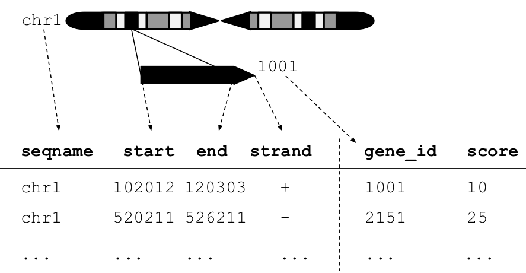

Bed files

## *GRanges*: Genomic Ranges

[figure not shown]

An illustration of genomic ranges. GRanges represents a set genomic ranges in terms of the sequence name (typically the chromosome), start and end coordinates (as an IRanges object), and strand (either positive, negative, or unstranded). GRanges holds information about its universe of sequences (typically a genome) and an arbitrary set of metadata columns with information particular to the dataset.

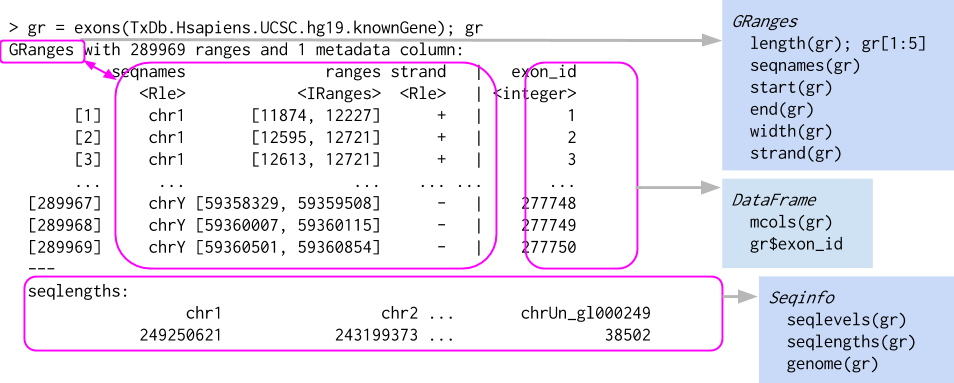

GRanges Object

The central genomic data structure is the *GRanges* class, which represents a collection of genomic ranges that each have a single start and end location on the genome. It can be used to store the location of genomic features such as binding sites, read alignments and transcripts.

## Constructing a *GRanges* object from data.frame

If we have a data.frame containing scores on a set of genomic ranges, we can call `makeGRangesFromDataFrame()` to promote the data.frame to a GRanges, thus adding semantics, formal constraints, and range-specific functionality. For example,

```r
suppressPackageStartupMessages({
 library(BiocStyle)
 library(GenomicRanges)
})
```

```r
df <- data.frame(
    seqnames = rep(c("chr1", "chr2", "chr1", "chr3"), c(1, 3, 2, 4)),
    start = c(101, 105, 125, 132, 134, 152, 153, 160, 166, 170),
    end = c(104, 120, 133, 132, 155, 154, 159, 166, 171, 190),
    strand = rep(strand(c("-", "+", "*", "+", "-")), c(1, 2, 2, 3, 2)),
    score = 1:10,
    GC = seq(1, 0, length=10),
    row.names = head(letters, 10))
gr <- makeGRangesFromDataFrame(df, keep.extra.columns=TRUE)
```

Here is another example where we load in a collection of CpG islands in the human genome described in [Wu et al., 2010](https://doi.org/10.1093/biostatistics/kxq005).

```r
library(GenomicRanges)
cpg <- read.delim("http://www.haowulab.org/software/makeCGI/model-based-cpg-islands-hg19.txt")
cpg <- makeGRangesFromDataFrame(cpg, keep.extra.columns = TRUE)
genome(cpg) <- "hg19"
cpg <- sort(cpg)
cpg
```

```
## GRanges object with 65699 ranges and 5 metadata columns:
##                 seqnames        ranges strand |    length  CpGcount GCcontent
##                    <Rle>     <IRanges>  <Rle> | <integer> <integer> <integer>
##       [1]           chr1   10497-11241      * |       745       110       549
##       [2]           chr1   28705-29791      * |      1087       115       792
##       [3]           chr1 135086-135805      * |       720        42       484
##       [4]           chr1 136164-137362      * |      1199        71       832
##       [5]           chr1 137665-138121      * |       457        22       301
##       ...            ...           ...    ... .       ...       ...       ...
##   [65695] chrUn_gl000243   29852-30145      * |       294        16       197
##   [65696] chrUn_gl000243   30367-30685      * |       319        30       232
##   [65697] chrUn_gl000244   15576-15797      * |       222        13       142
##   [65698] chrUn_gl000244   15954-16668      * |       715        43       449
##   [65699] chrUn_gl000244   17297-17767      * |       471        26       296
##               pctGC    obsExp
##           <numeric> <numeric>
##       [1]     0.737     1.106
##       [2]     0.729     0.818
##       [3]     0.672     0.548
##       [4]     0.694     0.524
##       [5]     0.659     0.475
##       ...       ...       ...
##   [65695]     0.670     0.488
##   [65696]     0.727     0.711
##   [65697]     0.640     0.584
##   [65698]     0.628     0.611
##   [65699]     0.628     0.559
##   -------
##   seqinfo: 81 sequences from hg19 genome; no seqlengths
```

## Loading a *GRanges* object from a standard file format

We often obtain data on genomic ranges from standard track formats, like BED, GFF and BigWig. The rtracklayer package parses those files directly into GRanges objects. The GenomicAlignments package parses BAM files into GAlignments objects, which behave much like GRanges, and it is easy to convert a GAlignments to a GRanges. We will see some examples of loading data from files later in the tutorial.

The `seqnames()`, `ranges()`, and `strand()` accessor functions extract the components of the genomic coordinates,

## Basic manipulation of *GRanges* objects

```r
seqnames(gr)
```

```
## factor-Rle of length 10 with 4 runs
##   Lengths:    1    3    2    4
##   Values : chr1 chr2 chr1 chr3
## Levels(3): chr1 chr2 chr3
```

```r
ranges(gr)
```

```
## IRanges object with 10 ranges and 0 metadata columns:
##         start       end     width
##     <integer> <integer> <integer>
##   a       101       104         4
##   b       105       120        16
##   c       125       133         9
##   d       132       132         1
##   e       134       155        22
##   f       152       154         3
##   g       153       159         7
##   h       160       166         7
##   i       166       171         6
##   j       170       190        21
```

```r
strand(gr)
```

```
## factor-Rle of length 10 with 5 runs
##   Lengths: 1 2 2 3 2
##   Values : - + * + -
## Levels(3): + - *
```

The `granges()` function extracts genomic ranges without corresponding metadata,

```r
granges(gr)
```

```
## GRanges object with 10 ranges and 0 metadata columns:
##     seqnames    ranges strand
##        <Rle> <IRanges>  <Rle>
##   a     chr1   101-104      -
##   b     chr2   105-120      +
##   c     chr2   125-133      +
##   d     chr2       132      *
##   e     chr1   134-155      *
##   f     chr1   152-154      +
##   g     chr3   153-159      +
##   h     chr3   160-166      +
##   i     chr3   166-171      -
##   j     chr3   170-190      -
##   -------
##   seqinfo: 3 sequences from an unspecified genome; no seqlengths
```

The `start()`, `end()`, `width()`, and `range` functions extract basic interval characteristics,

```r
start(gr)
```

```
##  [1] 101 105 125 132 134 152 153 160 166 170
```

```r
end(gr)
```

```
##  [1] 104 120 133 132 155 154 159 166 171 190
```

```r
width(gr)
```

```
##  [1]  4 16  9  1 22  3  7  7  6 21
```

The `mcols()` accessor extracts the metadata as a *DataFrame*,

```r
mcols(gr)
```

```
## DataFrame with 10 rows and 2 columns
##       score        GC
##   <integer> <numeric>
## a         1  1.000000
## b         2  0.888889
## c         3  0.777778
## d         4  0.666667
## e         5  0.555556
## f         6  0.444444
## g         7  0.333333
## h         8  0.222222
## i         9  0.111111
## j        10  0.000000
```

```r
mcols(gr)$score
```

```
##  [1]  1  2  3  4  5  6  7  8  9 10
```

```r
score(gr)
```

```
##  [1]  1  2  3  4  5  6  7  8  9 10
```

The lengths and other properties of the sequences containing the ranges can (and should) be stored in the *GRanges* object. Formal tracking of the sequence universe, typically the genome build, ensures data integrity and prevents accidental mixing of ranges from incompatible contexts. Assuming these data are of *Homo sapiens*, we could add the sequence information like this:

```r
seqinfo(gr) <- Seqinfo(genome="hg38")
```

The `Seqinfo()` function automatically loads the sequence information for the specified `genome=` by querying the UCSC database.

And then retrieves as:

```r
seqinfo(gr)
```

```
## Seqinfo object with 711 sequences (1 circular) from hg38 genome:
##   seqnames             seqlengths isCircular genome
##   chr1                  248956422      FALSE   hg38
##   chr2                  242193529      FALSE   hg38
##   chr3                  198295559      FALSE   hg38
##   chr4                  190214555      FALSE   hg38
##   chr5                  181538259      FALSE   hg38
##   ...                         ...        ...    ...
##   chr22_KQ759761v1_alt     145162      FALSE   hg38
##   chrX_KV766199v1_alt      188004      FALSE   hg38
##   chrX_MU273395v1_alt      619716      FALSE   hg38
##   chrX_MU273396v1_alt      294119      FALSE   hg38
##   chrX_MU273397v1_alt      330493      FALSE   hg38
```

Methods for accessing the `length` and `names` have also been defined.

```r
names(gr)
```

```
##  [1] "a" "b" "c" "d" "e" "f" "g" "h" "i" "j"
```

```r
length(gr)
```

```
## [1] 10
```

## Subsetting *GRanges* objects

*GRanges* objects act like vectors of ranges, with the expected vector-like subsetting operations available

```r
gr[2:3]
```

```
## GRanges object with 2 ranges and 2 metadata columns:
##     seqnames    ranges strand |     score        GC
##        <Rle> <IRanges>  <Rle> | <integer> <numeric>
##   b     chr2   105-120      + |         2  0.888889
##   c     chr2   125-133      + |         3  0.777778
##   -------
##   seqinfo: 711 sequences (1 circular) from hg38 genome
```

A second argument to the `[` subset operator specifies which metadata columns to extract from the *GRanges* object. For example,

```r
gr[2:3, "GC"]
```

```
## GRanges object with 2 ranges and 1 metadata column:
##     seqnames    ranges strand |        GC
##        <Rle> <IRanges>  <Rle> | <numeric>
##   b     chr2   105-120      + |  0.888889
##   c     chr2   125-133      + |  0.777778
##   -------
##   seqinfo: 711 sequences (1 circular) from hg38 genome
```

The `subset()` function provides an easy way to subset based on attributes of the ranges and columns in the metadata. For example,

```r
subset(gr, strand == "+" & score > 5, select = score)
```

```
## GRanges object with 3 ranges and 1 metadata column:
##     seqnames    ranges strand |     score
##        <Rle> <IRanges>  <Rle> | <integer>
##   f     chr1   152-154      + |         6
##   g     chr3   153-159      + |         7
##   h     chr3   160-166      + |         8
##   -------
##   seqinfo: 711 sequences (1 circular) from hg38 genome
```

Elements can also be assigned to the *GRanges* object. This example replaces the the second row of a *GRanges* object with the first row of `gr`.

```r
grMod <- gr
grMod[2] <- gr[1]
head(grMod, n=3)
```

```
## GRanges object with 3 ranges and 2 metadata columns:
##     seqnames    ranges strand |     score        GC
##        <Rle> <IRanges>  <Rle> | <integer> <numeric>
##   a     chr1   101-104      - |         1  1.000000
##   b     chr1   101-104      - |         1  1.000000
##   c     chr2   125-133      + |         3  0.777778
##   -------
##   seqinfo: 711 sequences (1 circular) from hg38 genome
```

## Basic interval operations for *GRanges* objects

There are many functions for manipulating *GRanges* objects. The functions can be classified as *intra-range functions*, *inter-range functions*, and *between-range functions*.

*Intra-range functions* operate on each element of a *GRanges* object independent of the other ranges in the object. For example, the `flank` function can be used to recover regions flanking the set of ranges represented by the *GRanges* object. So to get a *GRanges* object containing the ranges that include the 10 bases upstream according to the direction of “transcription” (indicated by the strand):

```r
g <- gr[1:3]
g <- append(g, gr[10])
flank(g, 10)
```

```
## GRanges object with 4 ranges and 2 metadata columns:
##     seqnames    ranges strand |     score        GC
##        <Rle> <IRanges>  <Rle> | <integer> <numeric>
##   a     chr1   105-114      - |         1  1.000000
##   b     chr2    95-104      + |         2  0.888889
##   c     chr2   115-124      + |         3  0.777778
##   j     chr3   191-200      - |        10  0.000000
##   -------
##   seqinfo: 711 sequences (1 circular) from hg38 genome
```

And to include the downstream bases:

```r
flank(g, 10, start=FALSE)
```

```
## GRanges object with 4 ranges and 2 metadata columns:
##     seqnames    ranges strand |     score        GC
##        <Rle> <IRanges>  <Rle> | <integer> <numeric>
##   a     chr1    91-100      - |         1  1.000000
##   b     chr2   121-130      + |         2  0.888889
##   c     chr2   134-143      + |         3  0.777778
##   j     chr3   160-169      - |        10  0.000000
##   -------
##   seqinfo: 711 sequences (1 circular) from hg38 genome
```

A common use case for `flank()` is generating promoter regions based on the transcript ranges. There is a convenience function that by default generates a region starting 2000bp upstream and 200bp downstream of the TSS,

```r
promoters(g)
```

```
## GRanges object with 4 ranges and 2 metadata columns:
##     seqnames    ranges strand |     score        GC
##        <Rle> <IRanges>  <Rle> | <integer> <numeric>
##   a     chr1  -95-2104      - |         1  1.000000
##   b     chr2 -1895-304      + |         2  0.888889
##   c     chr2 -1875-324      + |         3  0.777778
##   j     chr3   -9-2190      - |        10  0.000000
##   -------
##   seqinfo: 711 sequences (1 circular) from hg38 genome
```

To ignore strand/transcription and assume the orientation of left to right use `unstrand()`,

```r
flank(unstrand(g), 10)
```

```
## GRanges object with 4 ranges and 2 metadata columns:
##     seqnames    ranges strand |     score        GC
##        <Rle> <IRanges>  <Rle> | <integer> <numeric>
##   a     chr1    91-100      * |         1  1.000000
##   b     chr2    95-104      * |         2  0.888889
##   c     chr2   115-124      * |         3  0.777778
##   j     chr3   160-169      * |        10  0.000000
##   -------
##   seqinfo: 711 sequences (1 circular) from hg38 genome
```

Other examples of intra-range functions include `resize()` and `shift()`. The `shift()` function will move the ranges by a specific number of base pairs, and the `resize()` function will set a specific width, by default fixing the “transcription” start (or just the start when strand is “*“). The `fix=` argument controls whether the”start”, “end” or “center” is held constant.

```r
shift(g, 5)
```

```
## GRanges object with 4 ranges and 2 metadata columns:
##     seqnames    ranges strand |     score        GC
##        <Rle> <IRanges>  <Rle> | <integer> <numeric>
##   a     chr1   106-109      - |         1  1.000000
##   b     chr2   110-125      + |         2  0.888889
##   c     chr2   130-138      + |         3  0.777778
##   j     chr3   175-195      - |        10  0.000000
##   -------
##   seqinfo: 711 sequences (1 circular) from hg38 genome
```

```r
resize(g, 30)
```

```
## GRanges object with 4 ranges and 2 metadata columns:
##     seqnames    ranges strand |     score        GC
##        <Rle> <IRanges>  <Rle> | <integer> <numeric>
##   a     chr1    75-104      - |         1  1.000000
##   b     chr2   105-134      + |         2  0.888889
##   c     chr2   125-154      + |         3  0.777778
##   j     chr3   161-190      - |        10  0.000000
##   -------
##   seqinfo: 711 sequences (1 circular) from hg38 genome
```

The *GenomicRanges* help page `?"intra-range-methods"` summarizes these methods.

*Inter-range functions* involve comparisons between ranges in a single *GRanges* object and typically aggregate ranges. For instance, the `reduce()` function will merge overlapping and adjacent ranges to produce a minimal set of ranges representing the regions covered by the original set.

```r
reduce(gr)
```

```
## GRanges object with 8 ranges and 0 metadata columns:
##       seqnames    ranges strand
##          <Rle> <IRanges>  <Rle>
##   [1]     chr1   152-154      +
##   [2]     chr1   101-104      -
##   [3]     chr1   134-155      *
##   [4]     chr2   105-120      +
##   [5]     chr2   125-133      +
##   [6]     chr2       132      *
##   [7]     chr3   153-166      +
##   [8]     chr3   166-190      -
##   -------
##   seqinfo: 711 sequences (1 circular) from hg38 genome
```

```r
reduce(gr, ignore.strand=TRUE)
```

```
## GRanges object with 5 ranges and 0 metadata columns:
##       seqnames    ranges strand
##          <Rle> <IRanges>  <Rle>
##   [1]     chr1   101-104      *
##   [2]     chr1   134-155      *
##   [3]     chr2   105-120      *
##   [4]     chr2   125-133      *
##   [5]     chr3   153-190      *
##   -------
##   seqinfo: 711 sequences (1 circular) from hg38 genome
```

Rarely, it useful to complement the (reduced) ranges. Note that the universe is taken as the entire sequence span in all three strands (+, -, *), which is often surprising when working with unstranded ranges.

```r
gaps(g)
```

```
## GRanges object with 2137 ranges and 0 metadata columns:
##                     seqnames        ranges strand
##                        <Rle>     <IRanges>  <Rle>
##      [1]                chr1   1-248956422      +
##      [2]                chr1         1-100      -
##      [3]                chr1 105-248956422      -
##      [4]                chr1   1-248956422      *
##      [5]                chr2         1-104      +
##      ...                 ...           ...    ...
##   [2133] chrX_MU273396v1_alt      1-294119      -
##   [2134] chrX_MU273396v1_alt      1-294119      *
##   [2135] chrX_MU273397v1_alt      1-330493      +
##   [2136] chrX_MU273397v1_alt      1-330493      -
##   [2137] chrX_MU273397v1_alt      1-330493      *
##   -------
##   seqinfo: 711 sequences (1 circular) from hg38 genome
```

The `disjoin` function breaks up the ranges so that they do not overlap but still cover the same regions:

```r
disjoin(g)
```

```
## GRanges object with 4 ranges and 0 metadata columns:
##       seqnames    ranges strand
##          <Rle> <IRanges>  <Rle>
##   [1]     chr1   101-104      -
##   [2]     chr2   105-120      +
##   [3]     chr2   125-133      +
##   [4]     chr3   170-190      -
##   -------
##   seqinfo: 711 sequences (1 circular) from hg38 genome
```

The `coverage` function counts how many ranges overlap each position in the sequence universe of a *GRanges* object.

```r
cov <- coverage(g)
cov[1:3]
```

```
## RleList of length 3
## $chr1
## integer-Rle of length 248956422 with 3 runs
##   Lengths:       100         4 248956318
##   Values :         0         1         0
##
## $chr2
## integer-Rle of length 242193529 with 5 runs
##   Lengths:       104        16         4         9 242193396
##   Values :         0         1         0         1         0
##
## $chr3
## integer-Rle of length 198295559 with 3 runs
##   Lengths:       169        21 198295369
##   Values :         0         1         0
```

The coverage is stored compactly as an *RleList*, with one *Rle* vector per sequence. We can convert it to a *GRanges*.

```r
cov_gr <- GRanges(cov)
cov_gr
```

```
## GRanges object with 719 ranges and 1 metadata column:
##                     seqnames        ranges strand |     score
##                        <Rle>     <IRanges>  <Rle> | <integer>
##     [1]                 chr1         1-100      * |         0
##     [2]                 chr1       101-104      * |         1
##     [3]                 chr1 105-248956422      * |         0
##     [4]                 chr2         1-104      * |         0
##     [5]                 chr2       105-120      * |         1
##     ...                  ...           ...    ... .       ...
##   [715] chr22_KQ759761v1_alt      1-145162      * |         0
##   [716]  chrX_KV766199v1_alt      1-188004      * |         0
##   [717]  chrX_MU273395v1_alt      1-619716      * |         0
##   [718]  chrX_MU273396v1_alt      1-294119      * |         0
##   [719]  chrX_MU273397v1_alt      1-330493      * |         0
##   -------
##   seqinfo: 711 sequences from an unspecified genome
```

## Finding overlaps between *GRanges* objects

Interval overlapping is the process of comparing the ranges in two objects to determine if and when they overlap. As such, it is perhaps the most common operation performed on *GRanges* objects. To this end, the *GenomicRanges* package provides a family of interval overlap functions. The most general of these functions is `findOverlaps()`, which takes a query and a subject as inputs and returns a *Hits* object containing the index pairings for the overlapping elements.

Let us assume that we have three random data.frame objects, each with annoyingly differing ways of naming the columns defining the ranges,

```r
set.seed(66+105+111+99+49+56)

pos <- sample(1:200, size = 30L)
size <- 10L
end <- size + pos - 1L
chrom <- sample(paste0("chr", 1:3), size = 30L, replace = TRUE)
query_df <- data.frame(chrom = chrom,
                       start = pos,
                       end = end)
query_dfs <- split(query_df, 1:3)
q1 <- rename(query_dfs[[1L]], start = "pos")
q2 <- rename(query_dfs[[2L]], chrom = "ch", start = "st")
q3 <- rename(query_dfs[[3L]], end = "last")
```

The `makeGRangesFromDataFrame()` function can guess some of these, but not all of them, so we help it out,

```r
q1 <- makeGRangesFromDataFrame(q1, start.field = "pos")
q2 <- makeGRangesFromDataFrame(q2, seqnames.field = "ch",
                                 start.field = "st")
q3 <- makeGRangesFromDataFrame(q3, end.field = "last")
query <- mstack(q1, q2, q3, .index.var="replicate")
sort(query, by = ~ start)
```

```
## GRanges object with 30 ranges and 1 metadata column:
##      seqnames    ranges strand | replicate
##         <Rle> <IRanges>  <Rle> |     <Rle>
##   14     chr3      7-16      * |         2
##   23     chr2     15-24      * |         2
##    4     chr2     18-27      * |         1
##   21     chr3     22-31      * |         3
##   17     chr1     29-38      * |         2
##   ..      ...       ...    ... .       ...
##   13     chr2   179-188      * |         1
##   19     chr3   181-190      * |         1
##   20     chr3   186-195      * |         2
##   22     chr2   190-199      * |         1
##    2     chr3   192-201      * |         2
##   -------
##   seqinfo: 3 sequences from an unspecified genome; no seqlengths
```

Above, we use the convenient `mstack()` function, which stacks its arguments, populating the `.index.var=` column with the origin of each range (using the argument names or positions).

Perhaps the simplest overlap-based operation is `subsetByOverlaps()`, which extracts the elements in the query (the first argument) that overlap at least one element in the subject (the second).

```r
subject <- gr
subsetByOverlaps(query, subject, ignore.strand=TRUE)
```

```
## GRanges object with 8 ranges and 1 metadata column:
##      seqnames    ranges strand | replicate
##         <Rle> <IRanges>  <Rle> |     <Rle>
##    7     chr2   109-118      * |         1
##   19     chr3   181-190      * |         1
##    5     chr1   139-148      * |         2
##   20     chr3   186-195      * |         2
##    6     chr1   125-134      * |         3
##    9     chr1   100-109      * |         3
##   15     chr1    99-108      * |         3
##   30     chr1   146-155      * |         3
##   -------
##   seqinfo: 3 sequences from an unspecified genome; no seqlengths
```

In every call to an overlap operation, it is necessary to specify `ignore.strand=TRUE`, except in rare cases when we do not want ranges on opposite strands to be considered overlapping.

To generally compute on the overlaps, we call `findOverlaps()` to return a `Hits` object, which is essentially a bipartite graph matching query ranges to overlapping subject ranges.

```r
hits <- findOverlaps(query, subject, ignore.strand=TRUE)
```

We typically use the hits to perform one of two operations: join and aggregate. For example, we could inner join the scores from the subject using the query and subject indexes,

```r
joined <- query[queryHits(hits)]
joined$score <- subject$score[subjectHits(hits)]
```

The above carries over a single metadata column from the subject. Similar code would carry over other columns and even the ranges themselves.

Sometimes, we want to merge the matched query and subject ranges, typically by finding their intersection,

```r
ranges(joined) <- ranges(pintersect(joined, subject[subjectHits(hits)]))
```

The typical aggregation is counting the number of hits overlapping a query. In general, aggregation starts by grouping the subject hits by query hits, which we express as a coercion to a *List*,

```r
hitsByQuery <- as(hits, "List")
```

The result is an *IntegerList*, a type of *AtomicList*. *AtomicList* objects have many methods for efficient aggregation. In this case, we just call `lengths()` to get the count:

```r
counts <- lengths(hitsByQuery)
```

Since this a common operation, there are shortcuts,

```r
counts <- countQueryHits(hits)
```

or even shorter and more efficient,

```r
counts <- countOverlaps(query, subject, ignore.strand=TRUE)
unname(counts)
```

```
##  [1] 0 0 1 0 0 0 1 0 0 0 0 1 0 0 0 0 1 0 0 0 0 1 1 0 1 0 0 0 0 2
```

Often, we want to combine joins and aggregations. For example, we may want to annotate each query with the maximum score among the subject hits,

```r
query$maxScore <- max(extractList(subject$score, hitsByQuery))
subset(query, maxScore > 0)
```

```
## GRanges object with 8 ranges and 2 metadata columns:
##      seqnames    ranges strand | replicate  maxScore
##         <Rle> <IRanges>  <Rle> |     <Rle> <integer>
##    7     chr2   109-118      * |         1         2
##   19     chr3   181-190      * |         1        10
##    5     chr1   139-148      * |         2         5
##   20     chr3   186-195      * |         2        10
##    6     chr1   125-134      * |         3         5
##    9     chr1   100-109      * |         3         1
##   15     chr1    99-108      * |         3         1
##   30     chr1   146-155      * |         3         6
##   -------
##   seqinfo: 3 sequences from an unspecified genome; no seqlengths
```

# Plotting with GViz

```r
library(Gviz)
#This data comes with the GenomicRanges package
data(cpgIslands)
class(cpgIslands)
```

```
## [1] "GRanges"
## attr(,"package")
## [1] "GenomicRanges"
```

```r
chr <- as.character(unique(seqnames(cpgIslands)))
gen <- genome(cpgIslands)
atrack <- AnnotationTrack(cpgIslands, name = "CpG")
```

With our first track object being created we may now proceed to the plotting. There is a single function plotTracks that handles all of this, `plotTracks`. `plotTracks` is quite powerful and has a number of very useful additional arguments. For now we will keep things very simple and just plot the single CpG islands annotation track.

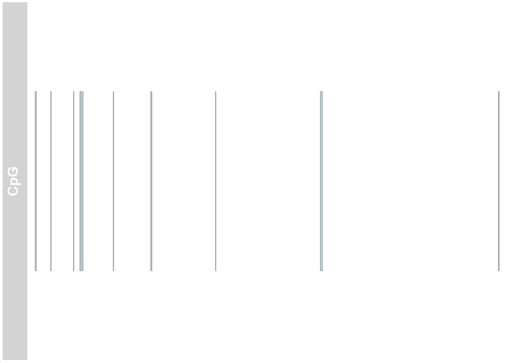

```r
plotTracks(atrack)
```

Apart from the relative distance of the CpG islands, this visualization does not tell us much. One obvious next step would be to indicate the genomic coordinates we are currently looking at in order to provide some reference. For this purpose, the `GenomeAxisTrack` class can be created.

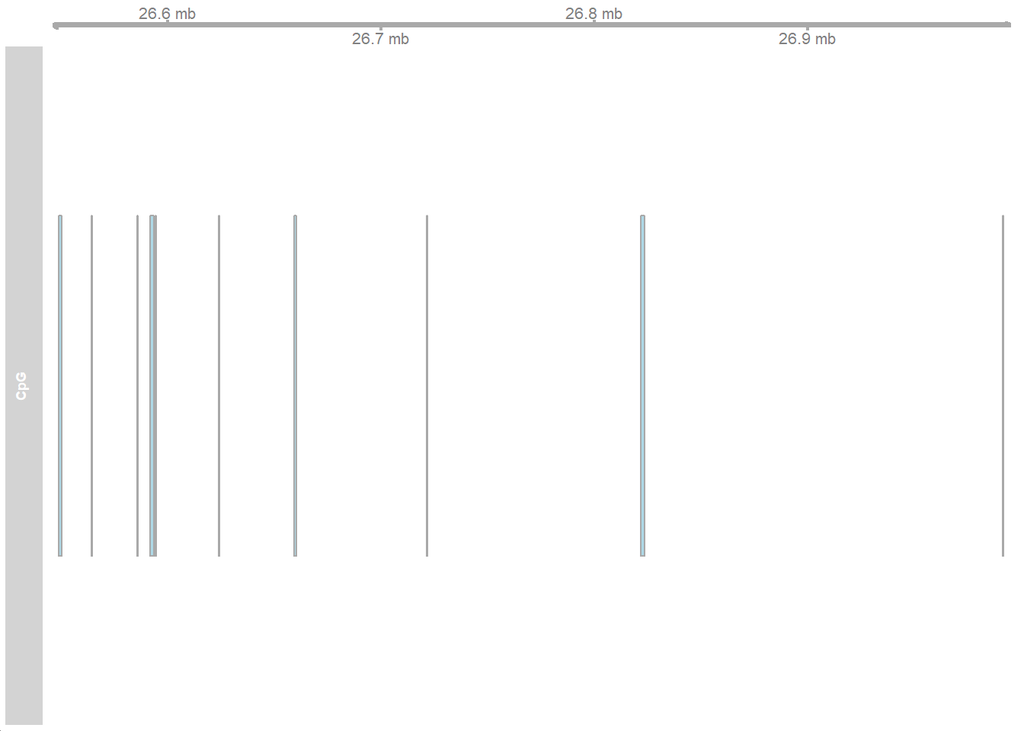

```r
gtrack <- GenomeAxisTrack()
plotTracks(list(gtrack, atrack))
```

A plotted track is always defined for exactly one chromosome on a particular genome. We can include this information in our plot by means of a chromosome ideogram. An ideogram is a simplified visual representation of a chromosome, with the different chromosomal staining bands indicated by color, and the centromere (if present) indicated by the shape. The necessary information to produce this visualization is stored in online data repositories, for instance at UCSC.

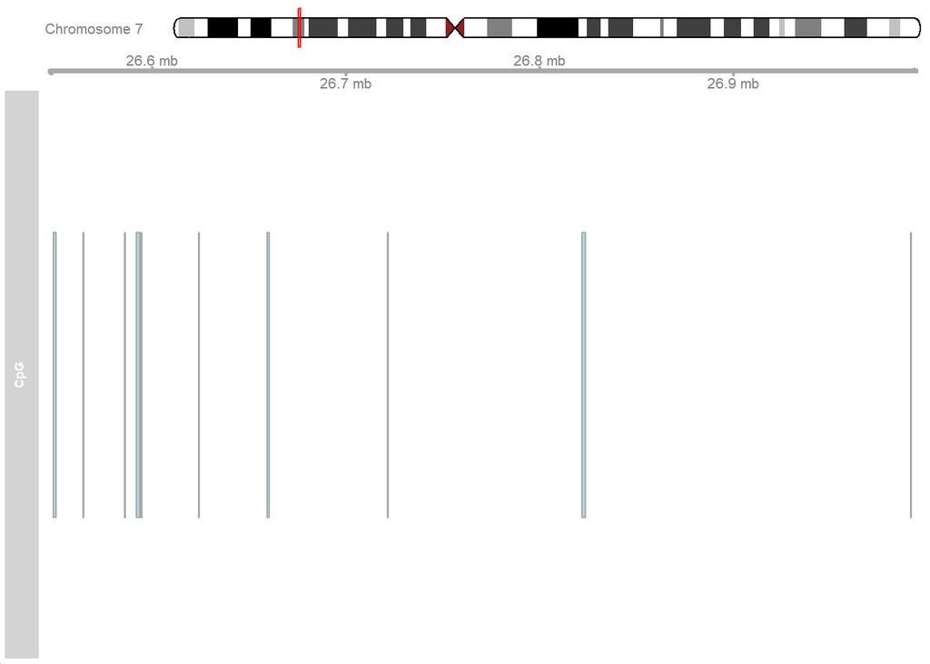

```r
itrack <- IdeogramTrack(genome = gen, chromosome = chr)
plotTracks(list(itrack, gtrack, atrack))
```

So far we have only looked at very basic annotation features and how to give a point of reference to our plots. Naturally, we also want to be able to handle more complex genomic features, such as gene models. The track class of choice here is a `GeneRegionTrack` object.

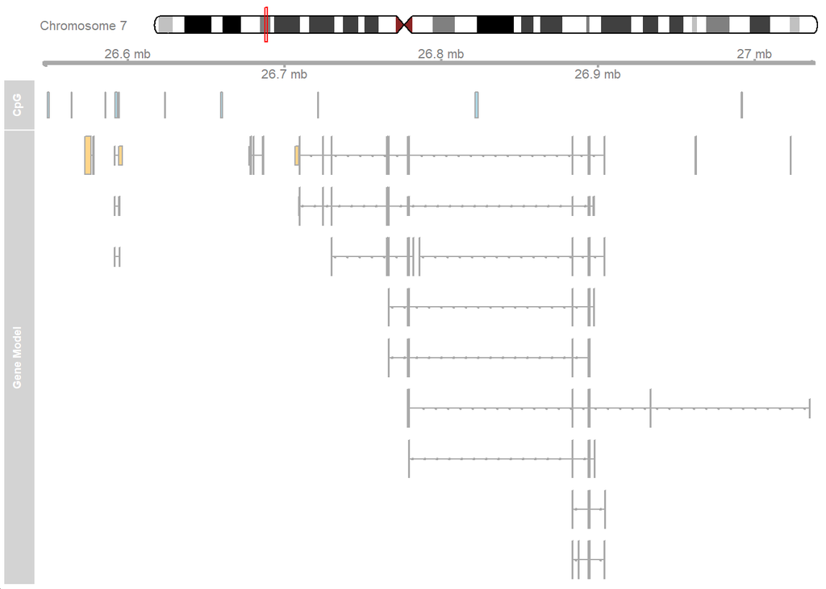

```r
data(geneModels)
grtrack <- GeneRegionTrack(geneModels, genome = gen,
                           chromosome = chr, name = "Gene Model")
plotTracks(list(itrack, gtrack, atrack, grtrack))
```

In all those previous examples the plotted genomic range has been determined automatically from the input tracks. Unless told otherwise, the package will always display the region from the leftmost item to the rightmost item in any of the tracks. `plotTracks` supports `from` and `to` arguments that let us choose an arbitrary genomic range to plot.

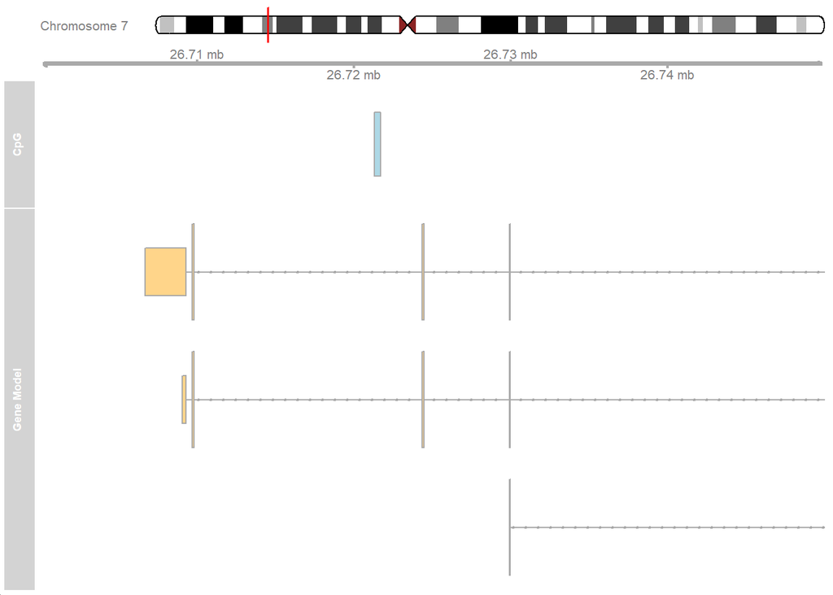

```r
plotTracks(list(itrack, gtrack, atrack, grtrack),
           from = 26700000, to = 26750000)
```

`extend.left` and `extend.right` can zoom out instead:

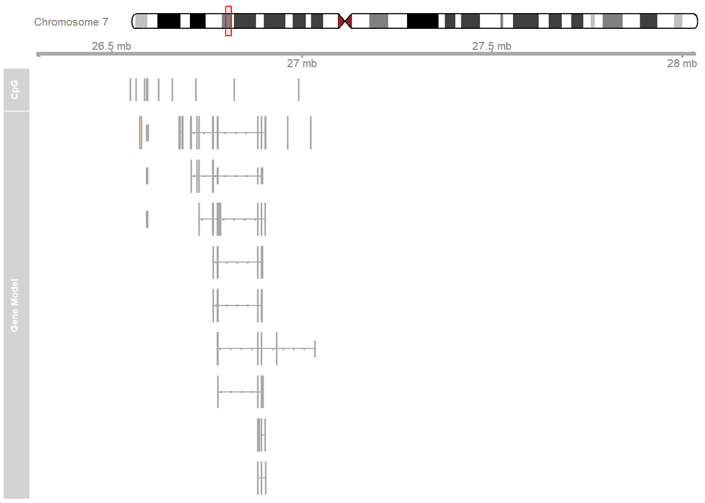

```r
plotTracks(list(itrack, gtrack, atrack, grtrack),
           extend.left = 0.5, extend.right = 1000000)
```

Often individual ranges on a plot tend to grow quite narrow, in particular when zooming far out, and a couple of tweaks become helpful in order to get nice plots, for instance to drop the bounding borders of the exons.

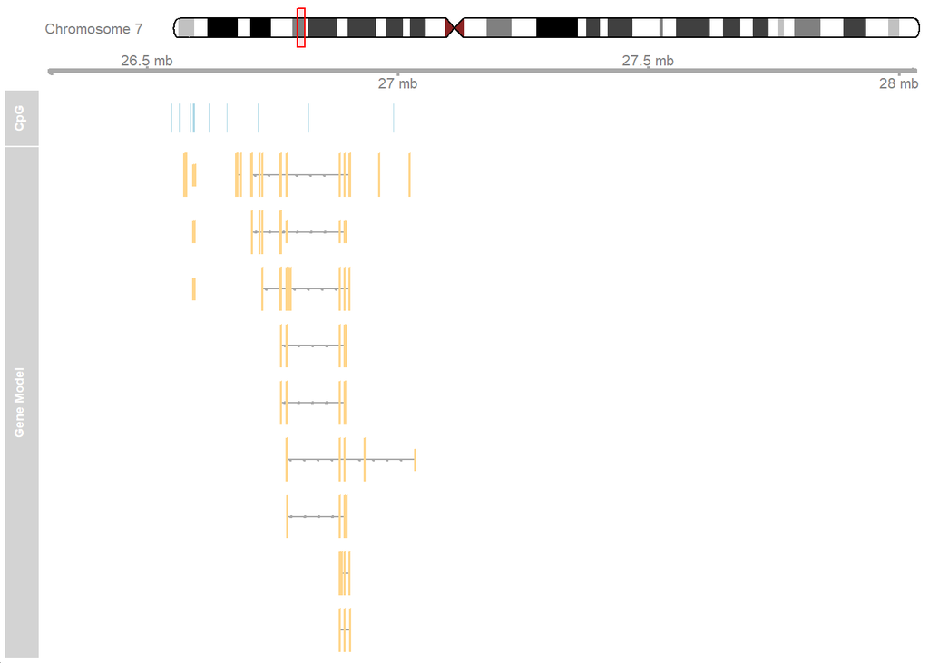

```r
plotTracks(list(itrack, gtrack, atrack, grtrack),
           extend.left = 0.5, extend.right = 1000000, col = NULL)
```

You might also, instead of larger ranges, want to zoom al the way into a sequence. We can show sequences using a `SequenceTrack`:

```r
library(BSgenome.Hsapiens.UCSC.hg19)
```

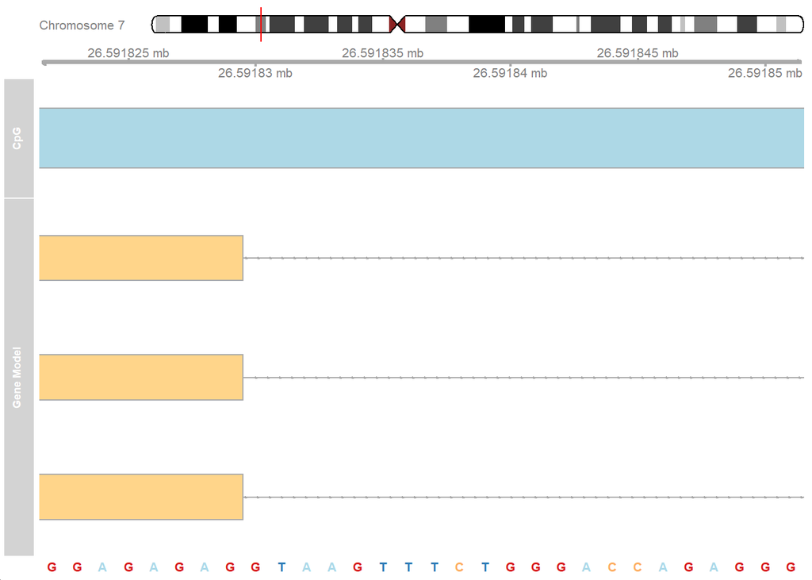

```r
strack <- SequenceTrack(Hsapiens, chromosome = chr)
plotTracks(list(itrack, gtrack, atrack, grtrack, strack),
           from = 26591822, to = 26591852, cex = 0.8)
```